# Data607_Project2_Codebase

Author

Shanice Smith

Published

October 12, 2026

## Introduction

The objective of Project 2 is to work through importing, tidying and prepping messy data for downstream analysis using `tidyr` and `dplyr`. The following datasets have been chosen, stored as raw CSV files, and could be found in my Week 5 Assignment directory on [GitHub](https://github.com/shanicesmith98/data-607-assignments/tree/main/week-5-assignment):

- Motherboard / Vice’s Car Thefts across the USA ([Discussion source](https://brightspace.cuny.edu/d2l/le/content/1344367/viewContent/41523045/View))
- Medical records ([Discussion source](https://brightspace.cuny.edu/d2l/le/content/1344367/viewContent/41523045/View))
- Highest Grossing Concert Tours by Women ([Discussion source](https://brightspace.cuny.edu/d2l/le/content/1344367/viewContent/41523045/View))

## Approach

As per the project requirements, each of the datasets will follow the same steps separately:

1. Import the raw CSV files from the GitHub directory to preserve the original or scrapped structure. If possible, I will mark any blank records as NA, where needed.
2. Read the csv file and inspect the structure of the files, then try to get the headers / columns to store as variables.
3. Reshape the datasets from a wide format into a long format using `pivot_longer()` , which will collapse the columns into rows.
4. Cleaning and tidying the datasets will happen next, to standardize variable names (casing, naming patterns, turning Y -> Yes), convert column/row data types to the appropriate formats (ex. dates, numeric). I’ll double check once more for any missing or NA records to make sure that’s documented and accounted for prior to calculations.
5. After, I can validate that the cleaned data is matching the unstructured data by verifying missing, duplicates or mislabeled variables are converted to the correct labeling.
6. Lastly, I’ll explore the cleaned and validated data by creating some graphs and charts with `ggplot2` for some simple analysis. Some questions I will have are how do Kia/Hyundai’s share of total vehicle thefts change over time, how the clinical measurements compare across diagnosis groups, and adjusted vs actual gross for the tour.

```r
# helper and import chunk
library(tidyverse)

set.seed(1234)

theme_set(
  theme_minimal(base_size = 12) +
    theme(axis.text = element_text(color = "grey20"),
          axis.title = element_text(color = "grey10"))
)

pct_label <- function(x) ifelse(is.na(x), "", paste0(round(x * 100), "%"))
```

## First Dataset — Kia/Hyundai thefts

**Challenges**

- For the car thefts, I anticipate the blank records being a challenge. The missing theft records from certain locations should not be counted as zeroes, but `NA`, which I can fix upon import of the file to avoid any complications - `na = c("", "N/A")`.
- Additionally, there are some inconsistencies of formatting of the locations, such as misspellings and the city/county pattern is not always enforced. Those will have to be fixed with a `case_when()` to catch before analysis.

### Loading in CSV

```r
car_thefts_raw_url <- "https://raw.githubusercontent.com/shanicesmith98/data-607-assignments/refs/heads/main/week-5-assignment/Motherboard_VICE_News_Kia_Hyundai_Theft_Dataset.csv"

car_theft_header_rows <- read_csv(car_thefts_raw_url, col_names = FALSE, n_max = 2,
                        col_types = cols(.default = "c"))

car_theft_data_body <- read_csv(car_thefts_raw_url, col_names = FALSE, skip = 2,
                       na = c("", "N/A"),
                       col_types = cols(.default = "c")) # skips double header rows
```

### Structure before tidying

```r
dim(car_theft_data_body)
```

```
[1]  45 211
```

```r
car_theft_header_rows[, 1:7]    # first two cities' worth of header
```

| X1 | X2 | X3 | X4 | X5 | X6 | X7 |
| --- | --- | --- | --- | --- | --- | --- |
| NA | Denver | NA | NA | El Paso | NA | NA |
| NA | Kia/Hyundais | All | Percent | Kia/Hyundais | All | Percent |

```r
car_theft_data_body[, 1:7]      # first two cities' worth of data
```

| X1 | X2 | X3 | X4 | X5 | X6 | X7 |
| --- | --- | --- | --- | --- | --- | --- |
| Dec/19 | 48 | 615 | 8% | 13 | 103 | 13% |
| Jan/20 | 21 | 519 | 4% | 9 | 95 | 9% |
| Feb/20 | 28 | 402 | 7% | 5 | 64 | 8% |
| Mar/20 | 35 | 508 | 7% | 6 | 75 | 8% |
| Apr/20 | 39 | 616 | 6% | 1 | 57 | 2% |
| May/20 | 37 | 692 | 5% | 1 | 62 | 2% |
| Jun/20 | 57 | 747 | 8% | 8 | 77 | 10% |
| Jul/20 | 57 | 786 | 7% | 5 | 62 | 8% |
| Aug/20 | 85 | 840 | 10% | 4 | 83 | 5% |
| Sep/20 | 107 | 916 | 12% | 2 | 73 | 3% |
| Oct/20 | 112 | 942 | 12% | 3 | 84 | 4% |
| Nov/20 | 155 | 948 | 16% | 2 | 72 | 3% |
| Dec/20 | 163 | 1,014 | 16% | 6 | 111 | 5% |
| Jan/21 | 209 | 1,039 | 20% | 5 | 111 | 5% |
| Feb/21 | 158 | 927 | 17% | 5 | 90 | 6% |
| Mar/21 | 166 | 948 | 18% | 9 | 81 | 11% |
| Apr/21 | 215 | 979 | 22% | 7 | 87 | 8% |
| May/21 | 242 | 1,068 | 23% | 5 | 66 | 8% |
| Jun/21 | 202 | 1,058 | 19% | 3 | 65 | 5% |
| Jul/21 | 174 | 1,063 | 16% | 5 | 102 | 5% |
| Aug/21 | 214 | 1,129 | 19% | 8 | 87 | 9% |
| Sep/21 | 195 | 1,045 | 19% | 8 | 89 | 9% |
| Oct/21 | 159 | 961 | 17% | 4 | 82 | 5% |
| Nov/21 | 231 | 1,056 | 22% | 5 | 86 | 6% |
| Dec/21 | 297 | 1,129 | 26% | 5 | 93 | 5% |
| Jan/22 | 327 | 1,161 | 28% | 8 | 94 | 9% |
| Feb/22 | 361 | 1,221 | 30% | 6 | 104 | 6% |
| Mar/22 | 427 | 1,301 | 33% | 5 | 133 | 4% |
| Apr/22 | 345 | 1,118 | 31% | 4 | 137 | 3% |
| May/22 | 356 | 1,215 | 29% | 9 | 142 | 6% |
| Jun/22 | 344 | 1,110 | 31% | 10 | 128 | 8% |
| Jul/22 | 464 | 1,198 | 39% | 17 | 125 | 14% |
| Aug/22 | 386 | 1,176 | 33% | 25 | 119 | 21% |
| Sep/22 | 427 | 1,229 | 35% | 8 | 137 | 6% |
| Oct/22 | 401 | 1,243 | 32% | 10 | 120 | 8% |
| Nov/22 | 339 | 1,075 | 32% | 13 | 128 | 10% |
| Dec/22 | 391 | 1,070 | 37% | 11 | 129 | 9% |
| Jan/23 | 424 | 1,170 | 36% | 6 | 150 | 4% |
| Feb/23 | 298 | 940 | 32% | 17 | 121 | 14% |
| Mar/23 | 209 | 917 | 23% | 15 | 168 | 9% |
| Apr/23 | 194 | 838 | 23% | 14 | 157 | 9% |
| May/23 | 285 | 964 | 30% | 17 | 183 | 9% |
| Jun/23 | 308 | 1,116 | 28% | 44 | 192 | 23% |
| Jul/23 | 233 | 1,005 | 23% | 33 | 144 | 23% |
| Aug/23 | NA | NA | NA | 24 | 187 | 13% |

We learn here that the data’s structure is 45 data rows by 211 columns. Column 1 has the month and year from `Dec/19` through `Aug/23`. Row 1 is a merged city header (a name followed by two empty cells) and row 2 repeats `Kia/Hyundais`, `All`, `Percent` for each of 70 geographies. City and measure are values stored as column names, so 9,450 observations sit in 210 columns.

### Transformation

```r
# Each city name appears once per three-column block, so two of every
# three header cells are empty and must be filled downward.
city_row    <- as.character(car_theft_header_rows[1, ])
measure_row <- as.character(car_theft_header_rows[2, ])

header_map <- tibble(
  position = seq_along(city_row),
  city     = str_trim(city_row),
  measure  = str_trim(measure_row)
) |>
  fill(city, .direction = "down")

n_distinct(header_map$city, na.rm = TRUE) # Output is 70 cities / column
```

```
[1] 70
```

```r
count(header_map, measure) # 3 measures, 70 columns each
```

| measure | n |
| --- | --- |
| All | 70 |
| Kia/Hyundais | 70 |
| Percent | 70 |
| NA | 1 |

Trailing space is seen on several measure labels, which is why `str_trim()` is needed. Otherwise, later in the transformation process, two separate columns for `All` would be created instead of one.

```r
# Combine city and measure into one name per column. "__" is used as the
# separator because no city name contains it, unlike "_", "," or " ".
new_names <- header_map |>
  mutate(col_name = if_else(position == 1,
                            "month",
                            str_c(city, measure, sep = "__"))) |>
  pull(col_name)

theft_named <- car_theft_data_body |> set_names(new_names)

names(theft_named)[1:7]
```

```
[1] "month"                 "Denver__Kia/Hyundais"  "Denver__All"
[4] "Denver__Percent"       "El Paso__Kia/Hyundais" "El Paso__All"
[7] "El Paso__Percent"
```

```r
theft_long <- theft_named |>
  pivot_longer(
    cols      = -month,
    names_to  = c("city", "measure"),
    names_sep = "__",
    values_to = "value"
  )

dim(theft_long)   # expect 9450 x 4
```

```
[1] 9450    4
```

```r
theft_tidy <- theft_long |>
  pivot_wider(names_from = measure, values_from = value) |>
  rename(
    kia_hyundai_thefts = `Kia/Hyundais`,
    all_thefts         = All,
    pct_reported       = Percent
  )

dim(theft_tidy)   # expect 3150 x 5
```

```
[1] 3150    5
```

### Variable types and naming

```r
theft_tidier <- theft_tidy |>
  mutate(
    # Turning source data format from "Dec/19" -> 2019-12-01
    month = parse_date(month, format = "%b/%y"),

    # Strip comma separators from numeric column: "1,014" -> 1014
    across(c(kia_hyundai_thefts, all_thefts), parse_number),

    # "8%" -> 8 -> 0.08, stored as a proportion for consistency
    pct_reported = parse_number(pct_reported) / 100,

    # Manually correcting typos and inconsistent formatting
    city = case_when(
      city == "Cincinatti"        ~ "Cincinnati",
      city == "Corpus Cristi, TX" ~ "Corpus Christi, TX",
      city == "Irving, Texas"     ~ "Irving, TX",
      TRUE ~ city
    )
  ) |>
  # Recompute the share rather than trusting the source column, which is
  # rounded to whole percents and blank for several reporting cities.
  mutate(
    pct_kia_hyundai = if_else(all_thefts > 0,
                              kia_hyundai_thefts / all_thefts,
                              NA_real_)
  )

glimpse(theft_tidier)
```

```
Rows: 3,150
Columns: 6
$ month              <date> 2019-12-01, 2019-12-01, 2019-12-01, 2019-12-01, 20…
$ city               <chr> "Denver", "El Paso", "Portland", "Atlanta", "Chicag…
$ kia_hyundai_thefts <dbl> 48, 13, 13, NA, 46, NA, 14, 25, 2, 21, 12, 9, 11, 6…
$ all_thefts         <dbl> 615, 103, 592, NA, 767, NA, NA, 430, NA, NA, 352, 3…
$ pct_reported       <dbl> 0.08, 0.13, 0.02, NA, 0.06, NA, NA, 0.06, NA, NA, 0…
$ pct_kia_hyundai    <dbl> 0.07804878, 0.12621359, 0.02195946, NA, 0.05997392,…
```

Column names are now using `snake_case` throughout with `kia_hyundai_thefts` and `all_thefts` count reported thefts per city-month.

### Missing-value decisions

```r
theft_tidier |>
  summarise(
    `City-months`      = n(),
    `Both counts`      = sum(!is.na(kia_hyundai_thefts) & !is.na(all_thefts)),
    `Kia count only`   = sum(!is.na(kia_hyundai_thefts) &  is.na(all_thefts)),
    `Total count only` = sum( is.na(kia_hyundai_thefts) & !is.na(all_thefts)),
    `Neither count`    = sum( is.na(kia_hyundai_thefts) &  is.na(all_thefts))
  )
```

| City-months | Both counts | Kia count only | Total count only | Neither count |
| --- | --- | --- | --- | --- |
| 3150 | 2793 | 143 | 145 | 69 |

Blank cells are kept as `NA` and not marked as zero. Some cities, such as Virginia Beach, Norfolk and Miami never report a total theft count; Frisco and Lincoln never report a Kia/Hyundai count; Atlanta, San Antonio and Henderson begin reporting only in January 2021. Treating those blanks as zeros would invent a denominator and hand me a fake 0% share. I’m not dropping the rows here either — the analysis below filters incomplete records only where they would break a calculation, so the counts above stay auditable.

### Analysis

I’m comparing each city’s mean monthly Kia/Hyundai share before and after July 2022, the month the theft method got popular on social media. A city needs at least 12 months before and 6 after to qualify, so no mean rests on one or two observations. The statistic is the gap between those means in percentage points.

```r
share_change <- theft_tidier |>
  filter(!is.na(pct_kia_hyundai)) |>
  mutate(period = if_else(month < as.Date("2022-07-01"), "pre", "post")) |>
  group_by(city, period) |>
  summarise(months = n(), mean_share = mean(pct_kia_hyundai), .groups = "drop") |>
  pivot_wider(names_from = period, values_from = c(months, mean_share)) |>
  filter(months_pre >= 12, months_post >= 6) |>
  mutate(change_pp = (mean_share_post - mean_share_pre) * 100) |>
  arrange(desc(change_pp))

nrow(share_change)   # cities meeting the coverage threshold
```

```
[1] 63
```

```r
share_change |>
  slice_max(change_pp, n = 10) |>
  transmute(
    City                       = city,
    `Share before (%)`         = round(mean_share_pre  * 100, 1),
    `Share Jul 2022 on (%)`    = round(mean_share_post * 100, 1),
    `Change (pct. points)`     = round(change_pp, 1),
    `Months (pre / post)`      = str_c(months_pre, " / ", months_post)
  )
top_cities <- share_change |> slice_max(change_pp, n = 6) |> pull(city)
```

Table 1

| City | Share before (%) | Share Jul 2022 on (%) | Change (pct. points) | Months (pre / post) |
| --- | --- | --- | --- | --- |
| Rochester, NY | 9.8 | 52.9 | 43.1 | 31 / 14 |
| Minneapolis, MN | 7.3 | 49.9 | 42.6 | 31 / 14 |
| Cincinnati | 10.3 | 52.6 | 42.2 | 30 / 12 |
| Buffalo, NY | 5.9 | 44.5 | 38.6 | 31 / 14 |
| Atlanta | 7.8 | 44.1 | 36.3 | 18 / 14 |
| Louisville | 5.4 | 37.3 | 31.9 | 30 / 13 |
| Washington, D.C. | 5.6 | 36.2 | 30.6 | 30 / 14 |
| Chicago | 6.3 | 36.6 | 30.3 | 31 / 14 |
| San Antonio | 9.3 | 39.1 | 29.8 | 18 / 6 |
| Henderson, NV | 4.3 | 33.1 | 28.7 | 18 / 14 |

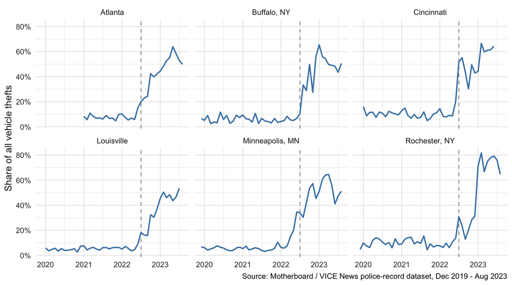

Figure 1: Kia/Hyundai share of reported vehicle thefts in the six cities with the largest increase. The dashed line marks July 2022.

```r
theft_tidier |>
  filter(city %in% top_cities, !is.na(pct_kia_hyundai)) |>
  ggplot(aes(x = month, y = pct_kia_hyundai)) +
  geom_vline(xintercept = as.Date("2022-07-01"),
             linetype = "dashed", color = "grey60") +
  geom_line(color = "steelblue", linewidth = 0.8) +
  facet_wrap(~ city) +
  scale_y_continuous(labels = pct_label) +
  scale_x_date(date_breaks = "1 year", date_labels = "%Y") +
  labs(
    x = NULL,
    y = "Share of all vehicle thefts",
    caption = "Source: Motherboard / VICE News police-record dataset, Dec 2019 - Aug 2023"
  )
```

```r
theft_tidier |>
  filter(city %in% top_cities) |>
  mutate(Month = format(month, "%b %Y"),
         share_pct = round(pct_kia_hyundai * 100, 1)) |>
  select(Month, month, city, share_pct) |>
  arrange(month) |>
  select(-month) |>
  pivot_wider(names_from = city, values_from = share_pct)
```

Table 2: Monthly Kia/Hyundai share of reported vehicle thefts (%) for the six cities in Figure 1. Blank cells are months the agency did not report.

| Month | Atlanta | Louisville | Buffalo, NY | Cincinnati | Rochester, NY | Minneapolis, MN |
| --- | --- | --- | --- | --- | --- | --- |
| Dec 2019 | NA | NA | 6.5 | NA | 4.7 | 6.7 |
| Jan 2020 | NA | 6.0 | 5.1 | 16.0 | 9.9 | 6.1 |
| Feb 2020 | NA | 3.6 | 9.0 | 8.8 | 7.5 | 4.3 |
| Mar 2020 | NA | 4.7 | 2.5 | 11.5 | 6.2 | 5.1 |
| Apr 2020 | NA | 5.7 | 3.8 | 11.5 | 12.1 | 6.1 |
| May 2020 | NA | 3.4 | 3.2 | 7.5 | 14.0 | 7.7 |
| Jun 2020 | NA | 5.4 | 11.7 | 11.7 | 13.1 | 6.5 |
| Jul 2020 | NA | 3.9 | 5.8 | 10.8 | 10.6 | 5.8 |
| Aug 2020 | NA | 4.1 | 8.9 | 8.1 | 8.6 | 4.5 |
| Sep 2020 | NA | 4.5 | 2.7 | 12.3 | 10.3 | 3.7 |
| Oct 2020 | NA | 5.3 | 4.5 | 11.1 | 6.0 | 4.0 |
| Nov 2020 | NA | 2.7 | 9.2 | 10.3 | 13.2 | 5.9 |
| Dec 2020 | NA | 7.4 | 7.3 | 9.5 | 8.7 | 6.5 |
| Jan 2021 | 8.2 | 7.6 | 9.4 | 12.7 | 9.1 | 5.4 |
| Feb 2021 | 5.7 | 4.3 | 6.3 | 15.0 | 12.9 | 7.3 |
| Mar 2021 | 10.9 | 5.7 | 6.1 | 9.0 | 14.1 | 4.4 |
| Apr 2021 | 8.3 | 6.4 | 3.8 | 6.8 | 14.4 | 5.1 |
| May 2021 | 6.8 | 5.0 | 10.7 | 9.8 | 9.2 | 6.1 |
| Jun 2021 | 7.0 | 4.2 | 2.6 | 6.9 | 10.8 | 5.5 |
| Jul 2021 | 6.2 | 6.1 | 6.7 | 7.5 | 9.5 | 3.9 |
| Aug 2021 | 9.0 | 6.3 | 4.6 | 11.9 | 15.5 | 3.2 |
| Sep 2021 | 6.6 | 5.2 | 4.1 | 4.9 | 4.4 | 4.0 |
| Oct 2021 | 6.8 | 6.1 | 3.1 | 6.6 | 9.2 | 4.3 |
| Nov 2021 | 4.8 | 6.4 | 6.7 | 10.3 | 6.7 | 5.6 |
| Dec 2021 | 10.0 | 6.3 | 3.4 | 11.1 | 7.9 | 10.5 |
| Jan 2022 | 10.2 | 5.1 | 4.3 | 14.4 | 7.6 | 6.2 |
| Feb 2022 | 7.3 | 7.1 | 5.0 | 8.2 | 6.2 | 5.8 |
| Mar 2022 | 5.4 | 5.6 | 8.3 | 7.9 | 9.7 | 7.5 |
| Apr 2022 | 7.0 | 3.6 | 5.4 | 9.1 | 6.1 | 14.7 |
| May 2022 | 5.8 | 4.5 | 5.1 | 8.6 | 10.7 | 20.0 |
| Jun 2022 | 15.1 | 9.1 | 6.7 | 20.2 | 13.6 | 34.7 |
| Jul 2022 | 20.1 | 18.1 | 10.4 | 51.5 | 30.8 | 34.1 |
| Aug 2022 | 22.9 | 16.3 | 33.3 | 55.2 | 23.4 | 30.4 |
| Sep 2022 | 24.4 | 15.8 | 28.9 | 43.7 | 12.9 | 42.2 |
| Oct 2022 | 42.4 | 32.5 | 49.7 | 30.2 | 20.2 | 53.6 |
| Nov 2022 | 39.9 | 30.4 | 27.6 | 49.5 | 28.2 | 57.3 |
| Dec 2022 | 42.2 | 37.1 | 56.0 | 43.0 | 31.3 | 45.4 |
| Jan 2023 | 44.5 | 45.6 | 65.5 | 44.2 | 71.4 | 51.0 |
| Feb 2023 | 48.3 | 50.5 | 55.9 | 66.6 | 81.8 | 60.8 |
| Mar 2023 | 52.7 | 46.0 | 54.4 | 59.8 | 66.8 | 64.0 |
| Apr 2023 | 55.2 | 48.4 | 49.7 | 61.1 | 75.0 | 64.6 |
| May 2023 | 63.9 | 43.6 | 49.1 | 61.4 | 78.0 | 56.1 |
| Jun 2023 | 58.4 | 46.6 | 48.3 | 64.4 | 79.3 | 41.1 |
| Jul 2023 | 53.0 | 53.4 | 43.5 | NA | 76.1 | 47.4 |
| Aug 2023 | 49.9 | NA | 50.6 | NA | 64.7 | 51.2 |

## Second Dataset — Medical records

**Challenges**

- Like the first dataset, I also anticipate the blank records being a challenge here with the medical records. The missing records from certain locations should not be counted as zeroes, but `NA`, which I can fix upon import of the file to avoid any complications - `na = c("", "nan", "N/A")`.
- Certain variables, such as Smoker, has inconsistent labeling and will need to be reformatted to one standardized pattern.

### Data source

```r
medical_records_raw_url <- "https://raw.githubusercontent.com/shanicesmith98/data-607-assignments/refs/heads/main/week-5-assignment/realworld_medical_dirty_dataset.csv"

# NA values have to be addressed here to avoid issues with 'nan' being turned into a catergory
medical_records_raw_data <- read_csv(
  medical_records_raw_url,
  na = c("", "nan", "N/A"),
  col_types = cols(
    Patient_ID     = col_character(),
    Age            = col_double(),
    Gender         = col_character(),
    Blood_Pressure = col_double(),
    Cholesterol    = col_double(),
    BMI            = col_double(),
    Smoker         = col_character(),
    Diagnosis      = col_character(),
    Admission_Date = col_date(format = "%Y-%m-%d"),
    Notes          = col_character()
  )
)
```

### Inspecting structure

```r
dim(medical_records_raw_data)
```

```
[1] 100  10
```

```r
names(medical_records_raw_data)
```

```
 [1] "Patient_ID"     "Age"            "Gender"         "Blood_Pressure"
 [5] "Cholesterol"    "BMI"            "Smoker"         "Diagnosis"
 [9] "Admission_Date" "Notes"
```

```r
head(medical_records_raw_data, 5)
```

| Patient_ID | Age | Gender | Blood_Pressure | Cholesterol | BMI | Smoker | Diagnosis | Admission_Date | Notes |
| --- | --- | --- | --- | --- | --- | --- | --- | --- | --- |
| P1000 | 55 | FEMALE | 120 | NA | 35.4 | Yes | Heart Disease | 2023-12-27 | NA |
| P1001 | 65 | Male | 150 | 180 | 27.8 | NA | None | 2023-01-01 | NA |
| P1002 | 45 | Male | 120 | 220 | 22.5 | No | NA | 2023-12-14 | NA |
| P1003 | 65 | Male | NA | 180 | 35.4 | No | NA | 2023-07-09 | NA |
| P1004 | 65 | Male | 120 | 300 | 40.1 | NA | None | 2023-07-10 | Follow-up required |

```r
sum(duplicated(medical_records_raw_data$Patient_ID))   # Output: 0
```

```
[1] 0
```

The raw file is 100 rows by 10 columns, one row per patient, with IDs `P1000` through `P1099` and no duplicates. Four of the columns (`Age`, `Blood_Pressure`, `Cholesterol`, `BMI`) are four separate measurements of the same patient, column names are inconsistently cased, and the categorical columns carry several spellings of the same value.

```r
count(medical_records_raw_data, Gender)
```

| Gender | n |
| --- | --- |
| FEMALE | 15 |
| Female | 17 |
| MALE | 21 |
| Male | 22 |
| male | 10 |
| NA | 15 |

```r
count(medical_records_raw_data, Smoker)
```

| Smoker | n |
| --- | --- |
| N | 20 |
| No | 20 |
| Y | 17 |
| Yes | 23 |
| NA | 20 |

```r
count(medical_records_raw_data, Diagnosis)
```

| Diagnosis | n |
| --- | --- |
| Diabetes | 27 |
| Heart Disease | 25 |
| None | 27 |
| NA | 21 |

```r
count(medical_records_raw_data, Notes)
```

| Notes | n |
| --- | --- |
| Checkup due | 18 |
| Follow-up required | 25 |
| Pending | 14 |
| NA | 43 |

`Gender` holds five spellings of two values (`Male`, `MALE`, `male`, `Female`, `FEMALE`). `Smoker` mixes `Yes`/`Y` and `No`/`N`. `Admission_Date` is the one column needing no treatment: valid ISO-8601 throughout.

### Consistent variable names

```r
# Using snake_case throughout
med <- medical_records_raw_data |>
  rename(
    patient_id     = Patient_ID,
    age_years      = Age,
    gender         = Gender,
    blood_pressure = Blood_Pressure,
    cholesterol    = Cholesterol,
    bmi            = BMI,
    smoker_raw     = Smoker,
    diagnosis      = Diagnosis,
    admission_date = Admission_Date,
    notes          = Notes
  )
```

### Standardizing inconsistent values

```r
med <- med |>
  mutate(
    # Five spellings collapse to two with one title-case call.
    gender = str_to_title(gender),

    # Yes/Y and No/N become a logical, which makes later proportions trivial.
    is_smoker = case_when(
      smoker_raw %in% c("Yes", "Y") ~ TRUE,
      smoker_raw %in% c("No",  "N") ~ FALSE,
      TRUE ~ NA
    ),

    # Diagnosis has BOTH a "None" level and missing values; these mean different things and are kept separate.
    # "None" = could mean examined, nothing found. NA = not recorded.
    diagnosis_group = if_else(is.na(diagnosis), "Not recorded", diagnosis)
  ) |>
  select(-smoker_raw)   # drop the raw column now that is_smoker exists

count(med, gender)
```

| gender | n |
| --- | --- |
| Female | 32 |
| Male | 53 |
| NA | 15 |

```r
count(med, is_smoker)
```

| is_smoker | n |
| --- | --- |
| FALSE | 40 |
| TRUE | 40 |
| NA | 20 |

```r
count(med, diagnosis_group)
```

| diagnosis_group | n |
| --- | --- |
| Diabetes | 27 |
| Heart Disease | 25 |
| None | 27 |
| Not recorded | 21 |

### Reshaping the measurements to long form

```r
med_tidy <- med |>
  pivot_longer(
    cols      = c(age_years, blood_pressure, cholesterol, bmi),
    names_to  = "measure",
    values_to = "value"
  ) |>
  mutate(
    unit = case_when(
      measure == "age_years"      ~ "years",
      measure == "blood_pressure" ~ "mmHg",
      measure == "cholesterol"    ~ "mg/dL",
      measure == "bmi"            ~ "kg/m2"
    ),
    measure_label = case_when(
      measure == "age_years"      ~ "Age",
      measure == "blood_pressure" ~ "Blood pressure",
      measure == "cholesterol"    ~ "Cholesterol",
      measure == "bmi"            ~ "BMI"
    ),
    facet_label = str_c(measure_label, " (", unit, ")")
  )

dim(med_tidy)   # Output: 400 x 12
```

```
[1] 400  12
```

The id columns — `patient_id`, `gender`, `is_smoker`, `diagnosis`, `admission_date`, `notes` — are left untouched by the pivot because they describe the *patient*, not the measurement. Only the four measured quantities move. The result is 100 patients × 4 measurements = 400 rows, which is the grain that lets one `group_by()` answer a question about all four measurements at once.

### Missing-value decisions

```r
med_tidy |>
  group_by(Measurement = facet_label) |>
  summarise(
    Patients   = n(),
    Reported   = sum(!is.na(value)),
    Missing    = sum(is.na(value)),
    `% missing` = round(100 * mean(is.na(value)), 1),
    .groups = "drop"
  )
```

Table 3

| Measurement | Patients | Reported | Missing | % missing |
| --- | --- | --- | --- | --- |
| Age (years) | 100 | 83 | 17 | 17 |
| BMI (kg/m2) | 100 | 80 | 20 | 20 |
| Blood pressure (mmHg) | 100 | 86 | 14 | 14 |
| Cholesterol (mg/dL) | 100 | 80 | 20 | 20 |

No row and no patient is dropped. Every summary below uses `na.rm = TRUE` and reports the number of patients behind each statistic in its own column.

### Analysis

We’re doing two comparisons on the long data. First, mean and median of each measurement by diagnosis group — I’m showing both because the measurements are pre-binned, and the median is the more honest summary of a discrete variable. Second, mean measurement for smokers against non-smokers. Counts go with every figure and nothing is imputed.

```r
med_summary <- med_tidy |>
  group_by(Measurement = facet_label, Diagnosis = diagnosis_group) |>
  summarise(
    Patients = sum(!is.na(value)),
    Mean     = round(mean(value,   na.rm = TRUE), 1),
    Median   = round(median(value, na.rm = TRUE), 1),
    .groups  = "drop"
  ) |>
  arrange(Measurement, Diagnosis)

med_summary
```

Table 4: Mean and median of each clinical measurement by diagnosis group, with the number of patients reporting each measurement. These are the values plotted in Figure 2.

| Measurement | Diagnosis | Patients | Mean | Median |
| --- | --- | --- | --- | --- |
| Age (years) | Diabetes | 22 | 47.7 | 55.0 |
| Age (years) | Heart Disease | 18 | 44.4 | 45.0 |
| Age (years) | None | 23 | 44.6 | 45.0 |
| Age (years) | Not recorded | 20 | 52.0 | 55.0 |
| BMI (kg/m2) | Diabetes | 22 | 31.0 | 28.9 |
| BMI (kg/m2) | Heart Disease | 21 | 32.8 | 35.4 |
| BMI (kg/m2) | None | 20 | 33.0 | 35.4 |
| BMI (kg/m2) | Not recorded | 17 | 32.1 | 35.4 |
| Blood pressure (mmHg) | Diabetes | 21 | 138.6 | 140.0 |
| Blood pressure (mmHg) | Heart Disease | 23 | 137.8 | 140.0 |
| Blood pressure (mmHg) | None | 24 | 137.9 | 140.0 |
| Blood pressure (mmHg) | Not recorded | 18 | 133.3 | 130.0 |
| Cholesterol (mg/dL) | Diabetes | 21 | 229.0 | 220.0 |
| Cholesterol (mg/dL) | Heart Disease | 20 | 233.0 | 220.0 |
| Cholesterol (mg/dL) | None | 19 | 220.5 | 200.0 |
| Cholesterol (mg/dL) | Not recorded | 20 | 224.0 | 220.0 |

```r
smoker_summary <- med_tidy |>
  filter(!is.na(is_smoker), !is.na(value)) |>
  group_by(Measurement = facet_label, is_smoker) |>
  summarise(n = n(), mean_value = mean(value), .groups = "drop") |>
  pivot_wider(names_from = is_smoker, values_from = c(n, mean_value)) |>
  transmute(
    Measurement,
    `Smokers (n)`      = n_TRUE,
    `Smokers mean`     = round(mean_value_TRUE,  1),
    `Non-smokers (n)`  = n_FALSE,
    `Non-smokers mean` = round(mean_value_FALSE, 1),
    Difference         = round(mean_value_TRUE - mean_value_FALSE, 1)
  )

smoker_summary
```

Table 5

| Measurement | Smokers (n) | Smokers mean | Non-smokers (n) | Non-smokers mean | Difference |
| --- | --- | --- | --- | --- | --- |
| Age (years) | 29 | 45.7 | 35 | 47.0 | -1.3 |
| BMI (kg/m2) | 34 | 31.5 | 32 | 32.7 | -1.2 |
| Blood pressure (mmHg) | 34 | 135.9 | 34 | 140.3 | -4.4 |
| Cholesterol (mg/dL) | 32 | 224.4 | 35 | 224.9 | -0.5 |

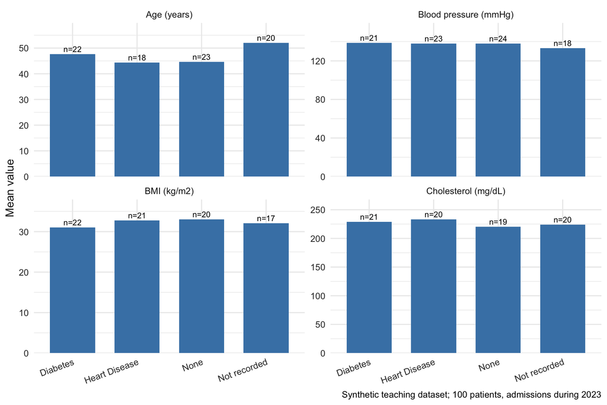

Figure 2: Mean value of each clinical measurement by diagnosis group, labelled with the number of patients reporting that measurement.

```r
med_summary |>
  ggplot(aes(x = Diagnosis, y = Mean)) +
  geom_col(fill = "steelblue", width = 0.7) +
  geom_text(aes(label = str_c("n=", Patients)), vjust = -0.4, size = 3) +
  facet_wrap(~ Measurement, scales = "free_y") +
  scale_y_continuous(expand = expansion(mult = c(0, 0.15))) +
  labs(
    x = NULL,
    y = "Mean value",
    caption = "Synthetic teaching dataset; 100 patients, admissions during 2023"
  ) +
  theme(axis.text.x = element_text(angle = 20, hjust = 1))
```

## Third Dataset — Highest Grossing Concert Tours by Women

**Challenges**

- Rank 7 shows up twice (Celine Dion, Pink) and rank 8 is missing, so I can’t trust `Rank` as an identifier and will rank the tours myself.
- The format for the numeric variables will need to be stripped to be solely numbers by removing the dollar signs and commas for more reliable calculations.

### Import Data

```r
high_grossing_women_tours_raw_url <- "https://raw.githubusercontent.com/shanicesmith98/data-607-assignments/refs/heads/main/week-5-assignment/tours_dataset.csv"

# Everything reads as text: currency columns carry "$" and thousands
# separators, and several numeric cells end in a footnote marker.
tours_raw_data <- read_csv(high_grossing_women_tours_raw_url, col_types = cols(.default = "c"))
```

### Structure before tidying

```r
dim(tours_raw_data)
```

```
[1] 20 11
```

```r
names(tours_raw_data)
```

```
 [1] "Rank"                             "Peak"
 [3] "All Time Peak"                    "Actual gross"
 [5] "Adjusted gross (in 2022 dollars)" "Artist"
 [7] "Tour title"                       "Year(s)"
 [9] "Shows"                            "Average gross"
[11] "Ref."
```

```r
head(tours_raw_data, 5)
```

| Rank | Peak | All Time Peak | Actual gross | Adjusted gross (in 2022 dollars) | Artist | Tour title | Year(s) | Shows | Average gross | Ref. |
| --- | --- | --- | --- | --- | --- | --- | --- | --- | --- | --- |
| 1 | 1 | 2 | $780,000,000 | $780,000,000 | Taylor Swift | The Eras Tour † | 2023–2024 | 56 | $13,928,571 | [1] |
| 2 | 1 | 7[2] | $579,800,000 | $579,800,000 | Beyoncé | Renaissance World Tour | 2023 | 56 | $10,353,571 | [3] |
| 3 | 1[4] | 2[5] | $411,000,000 | $560,622,615 | Madonna | Sticky & Sweet Tour ‡[4][a] | 2008–2009 | 85 | $4,835,294 | [6] |
| 4 | 2[7] | 10[7] | $397,300,000 | $454,751,555 | Pink | Beautiful Trauma World Tour | 2018–2019 | 156 | $2,546,795 | [7] |
| 5 | 2[4] | NA | $345,675,146 | $402,844,849 | Taylor Swift | Reputation Stadium Tour | 2018 | 53 | $6,522,173 | [8] |

Twenty rows by 11 columns, one row per tour. Four problems are visible in the head: currency stored as text (`"$780,000,000"`), footnote markers inside otherwise numeric cells (`"2[5]"`, `"$229,100,000[b]"`), status symbols inside the tour title (`"The Eras Tour †"`), and a year *range* in a single column (`"2023–2024"`) that holds two variables.

```r
# The two currency column names contain a non-breaking space (U+00A0),
# not a regular space. They look identical on screen, so a rename()
# matching "Actual gross" fails silently.
str_detect(names(tours_raw_data), "\u00a0")
```

```
 [1] FALSE FALSE FALSE  TRUE  TRUE FALSE FALSE FALSE FALSE FALSE FALSE
```

A fifth problem is not visible at all: `Rank` is not unique. Rank 7 appears twice and rank 8 is absent, so the column cannot serve as a key.

### Repairing the column names

```r
# Replace non-breaking spaces with ordinary ones before renaming anything.
names(tours_raw_data) <- names(tours_raw_data) |>
  str_replace_all("\u00a0", " ") |>
  str_trim()

tours <- tours_raw_data |>
  rename(
    source_rank    = Rank,
    peak           = Peak,
    all_time_peak  = `All Time Peak`,
    actual_gross   = `Actual gross`,
    adjusted_gross = `Adjusted gross (in 2022 dollars)`,
    artist         = Artist,
    tour_title     = `Tour title`,
    years          = `Year(s)`,
    shows          = Shows,
    average_gross  = `Average gross`,
    source_ref     = `Ref.`
  )
```

### Capturing the footnote markers before deleting them

```r
# The dagger marks tours still running when the table was compiled, which
# means their grosses are partial. That is real information, so it is
# captured as a column BEFORE the symbol is stripped out.
tours <- tours |>
  mutate(
    is_ongoing   = str_detect(tour_title, "\u2020"),   # †
    has_marker   = str_detect(tour_title, "[\u2021*]") # ‡ and *
  )

sum(tours$is_ongoing)   # expect 2
```

```
[1] 2
```

```r
sum(tours$has_marker)   # expect 3
```

```
[1] 3
```

The source page’s legend is not part of the CSV, so the meaning of `‡` and `*` cannot be recovered from this file. They are recorded in `has_marker` and flagged as an open question rather than guessed at; the two `†` tours are treated as incomplete throughout.

### Converting text to numbers

```r
# Remove bracketed footnote references like [4], [a], [21].
strip_notes <- function(x) str_remove_all(x, "\\[[0-9a-z]+\\]")

tours <- tours |>
  mutate(
    # Titles: drop footnotes AND status symbols, then trim the leftover space
    tour_title = tour_title |>
      strip_notes() |>
      str_remove_all("[\u2020\u2021*]") |>
      str_trim(),

    # Peaks: footnotes removed first, then integer conversion
    across(c(peak, all_time_peak), ~ as.integer(strip_notes(.x))),

    # Currency: footnotes first, then parse_number() strips "$" and commas
    across(c(actual_gross, adjusted_gross, average_gross),
           ~ parse_number(strip_notes(.x))),

    across(c(source_rank, shows), as.integer)
  )
```

### Splitting the year range

```r
tours <- tours |>
  separate_wider_delim(
    years,
    delim   = "\u2013",                        # EN-DASH, not a hyphen
    names   = c("year_start", "year_end"),
    too_few = "align_start"                    # single-year tours get NA
  ) |>
  mutate(
    across(c(year_start, year_end), as.integer),
    year_end = coalesce(year_end, year_start), # a one-year tour ends the year it starts
    tour_years = year_end - year_start + 1
  )
```

### Reshaping the two gross figures to long form

```r
tours_tidy <- tours |>
  # average_gross is derived (actual_gross / shows) and is recomputed below;
  # source_ref is a citation artifact belonging in Sources, not in the data.
  select(-average_gross, -source_ref) |>
  pivot_longer(
    cols      = c(actual_gross, adjusted_gross),
    names_to  = "gross_basis",
    values_to = "gross_usd"
  ) |>
  mutate(
    gross_basis = if_else(gross_basis == "actual_gross",
                          "Nominal (as earned)",
                          "Adjusted to 2022 USD")
  )

dim(tours_tidy)   # expect 40 x 13
```

```
[1] 40 13
```

Nominal and inflation-adjusted dollars are the same quantity measured on two bases. Side by side in separate columns they invite direct comparison of figures that are not comparable; stacked, the basis becomes an explicit grouping variable and every chart and table must declare which one it uses.

### Why the derived column is recomputed

```r
tours |>
  mutate(
    recomputed = actual_gross / shows,
    difference = round(average_gross - recomputed, 0)
  ) |>
  filter(abs(difference) > 1) |>
  select(tour_title, shows, actual_gross, average_gross, recomputed, difference)
```

| tour_title | shows | actual_gross | average_gross | recomputed | difference |
| --- | --- | --- | --- | --- | --- |
| The Monster Ball Tour | 203 | 227400000 | 1118227 | 1120197 | -1970 |

I’m comparing the two gross bases by ranking every tour twice, once on nominal and once on adjusted gross, then taking the difference. That difference shows how much inflation adjustment moves the standings. Revenue per show is recomputed as `actual_gross / shows` and reported only for the 18 completed tours, since the two ongoing ones have partial grosses against partial show counts.

### Analysis

The analysis compares the two gross bases. Each tour is ranked twice — once by nominal gross and once by inflation-adjusted gross — and the difference between those ranks measures how much inflation adjustment changes the standings. Revenue per show is recomputed as `actual_gross / shows` and reported separately for the 18 completed tours, since the two ongoing tours have partial grosses against a partial show count.

```r
rank_shift <- tours |>
  mutate(
    rank_nominal  = rank(-actual_gross,   ties.method = "min"),
    rank_adjusted = rank(-adjusted_gross, ties.method = "min"),
    rank_change   = rank_nominal - rank_adjusted   # positive = climbs
  ) |>
  arrange(rank_adjusted)
```

```r
rank_shift |>
  filter(abs(rank_change) >= 2) |>
  transmute(
    Artist                  = artist,
    Tour                    = tour_title,
    Years                   = str_c(year_start, "-", year_end),
    `Nominal rank`          = rank_nominal,
    `Adjusted rank`         = rank_adjusted,
    `Places moved`          = rank_change
  )
```

Table 6

| Artist | Tour | Years | Nominal rank | Adjusted rank | Places moved |
| --- | --- | --- | --- | --- | --- |
| Cher | Living Proof: The Farewell Tour | 2002-2005 | 14 | 10 | 4 |
| Madonna | Confessions Tour | 2006-2006 | 15 | 13 | 2 |
| Pink | Summer Carnival | 2023-2024 | 8 | 14 | -6 |
| Katy Perry | Prismatic World Tour | 2014-2015 | 13 | 15 | -2 |

```r
tours |>
  filter(!is_ongoing) |>
  mutate(gross_per_show = actual_gross / shows) |>
  slice_max(gross_per_show, n = 8) |>
  transmute(
    Artist              = artist,
    Tour                = tour_title,
    Shows               = shows,
    `Actual gross ($M)` = round(actual_gross / 1e6, 1),
    `Per show ($M)`     = round(gross_per_show / 1e6, 2)
  )
```

Table 7

[output not shown]

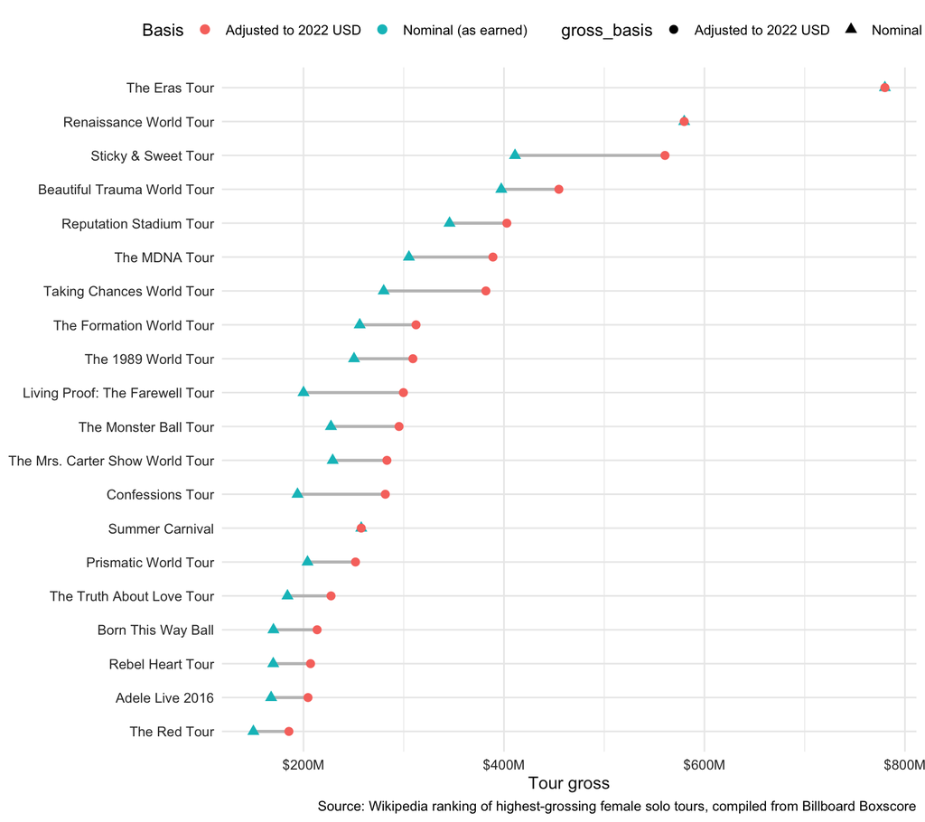

```r
# Order the y-axis by adjusted gross so the chart reads as a ranking
title_order <- tours |> arrange(adjusted_gross) |> pull(tour_title)

tours_tidy |>
  mutate(tour_title = factor(tour_title, levels = title_order)) |>
  ggplot(aes(x = gross_usd / 1e6, y = tour_title)) +
  geom_line(aes(group = tour_title), color = "grey75", linewidth = 1) +
  geom_point(aes(color = gross_basis, shape = gross_basis), size = 2.6) +
  scale_x_continuous(labels = function(x) paste0("$", x, "M")) +
  labs(
    x       = "Tour gross",
    y       = NULL,
    color   = "Basis",
    caption = "Source: Wikipedia ranking of highest-grossing female solo tours, compiled from Billboard Boxscore"
  ) +
  theme(legend.position = "top")
```

```r
tours |>
  arrange(desc(adjusted_gross)) |>
  transmute(
    Artist                = artist,
    Tour                  = tour_title,
    `Nominal gross ($M)`  = round(actual_gross   / 1e6, 1),
    `Adjusted gross ($M)` = round(adjusted_gross / 1e6, 1),
    `Difference ($M)`     = round((adjusted_gross - actual_gross) / 1e6, 1)
  )
```

Table 8: Nominal and inflation-adjusted gross for each tour in millions of US dollars, ordered by adjusted gross. These are the values plotted in Figure 3.

[output not shown]

## Credit

Throughout the assignment, Claude (Opus 5) was used to help plan, explain concepts, flag data issues, and debug errors. I ran and verified all code in RStudio, checked the reported figures against the raw files, and wrote the final interpretations myself.

Anthropic. (2026). Claude (Opus 5) [Large language model].